# Plant distances

# Introduction

In this notebook we will calculate genetic distances between plant populations to use as covariates in the BEDASSLE model. To make sure we have valid distances (i. e., Euclidean), we will use the average nucleotide distance as our metric.

Let’s start by reading packages:

```r
library(tidyverse)
library(broom)
rm(list=ls())
```

# Reading distances

Prior to this, we used [ANGSD](https://github.com/ANGSD/angsd) and [pcANGSD](https://github.com/Rosemeis/pcangsd) to calculate genotype probabilities for samples of **Syagrus** while considering genetic covariance between samples. We then used [NGSdist](https://github.com/fgvieira/ngsDist) to estimate pairwise nucleotide distances based on these genotype probabilities.

Let’s read the output file with these distances and prepare a data.frame with the data.

```r
dists = readr::read_delim('../ANGSD_plants/coronata_and_botryophora/syagrus_dists.txt',delim = '\t',  skip=2,col_names = FALSE)
samples = dists[[1]] %>%
  stringr::str_extract('BdM[:alnum:]+')
dists = as.matrix(dists[-1])
rownames(dists) = colnames(dists) = samples
dists = as.dist(dists) %>%
  broom::tidy(upper=T, diag=F) %>%
  rename(sample1 = item1,
         sample2 = item2)
dists
```

| sample1 | sample2 | distance |
| --- | --- | --- |
| BdM1592 | BdM1590 | 0.005271259 |
| BdM1594 | BdM1590 | 0.005621672 |
| BdM1607 | BdM1590 | 0.006151602 |
| BdM1622 | BdM1590 | 0.015870665 |
| BdM1637 | BdM1590 | 0.005311083 |
| BdM1638 | BdM1590 | 0.006511160 |
| BdM1639 | BdM1590 | 0.006690837 |
| BdM1640 | BdM1590 | 0.015424735 |
| BdM1656 | BdM1590 | 0.006470406 |
| BdM1658 | BdM1590 | 0.005881164 |

[output cut: 990 more lines]

These distances are between samples, and we want between populations, so we need to add data about populations and get average distances between populations. Let’s read a data table, merge with distance data.frame and summarize.

Read sample data and select important columns

```r
plant_data = readr::read_csv('plant_data.csv') %>%
  select(sample = genomics,
         population = pop_id_thesis)
plant_data
```

[output not shown]

[output cut: 67 more lines]

Replace samples by populations. To make it easier, we will transform the population data into a named vector and use `mutate` to do this replacement

```r
pops = plant_data$population
names(pops) = plant_data$sample
dists = dists %>%
  mutate(pop1 = pops[as.character(sample1)],
         pop2 = pops[as.character(sample2)])
dists
```

| sample1 | sample2 | distance | pop1 | pop2 |
| --- | --- | --- | --- | --- |
| BdM1592 | BdM1590 | 0.005271259 | P5 | P9 |
| BdM1594 | BdM1590 | 0.005621672 | P20 | P9 |
| BdM1607 | BdM1590 | 0.006151602 | P15 | P9 |
| BdM1622 | BdM1590 | 0.015870665 | P10 | P9 |
| BdM1637 | BdM1590 | 0.005311083 | P6 | P9 |
| BdM1638 | BdM1590 | 0.006511160 | P19 | P9 |
| BdM1639 | BdM1590 | 0.006690837 | P17_hyb | P9 |
| BdM1640 | BdM1590 | 0.015424735 | P3 | P9 |
| BdM1656 | BdM1590 | 0.006470406 | P17_cor | P9 |
| BdM1658 | BdM1590 | 0.005881164 | P5 | P9 |

[output cut: 990 more lines]

Now we can remove lines corresponding to within-population comparisons (which will all be set to 0) and average distances between populations.

```r
pop_dists = dists %>%
  filter(pop1 != pop2) %>%
  group_by(pop1,pop2) %>%
  summarise(distance = mean(distance)) %>%
  spread(key=pop2,value=distance)
pop_dists
```

| pop1 | P1 | P10 | P11 | P12 | P13 | P15 | P17_cor | P17_hyb | P19 | P2 | P20 | P3 | P4 | P5 | P6 | P7 | P8 | P9 |
| --- | --- | --- | --- | --- | --- | --- | --- | --- | --- | --- | --- | --- | --- | --- | --- | --- | --- | --- |
| P1 | NA | 0.002502235 | 0.015932571 | 0.002682661 | 0.014914126 | 0.014320722 | 0.014002080 | 0.014546327 | 0.014515643 | 0.015693483 | 0.015032758 | 0.002756036 | 0.016334113 | 0.014892128 | 0.015366299 | 0.015664997 | 0.002409524 | 0.015826624 |
| P10 | 0.002502235 | NA | 0.015871471 | 0.002669173 | 0.014837147 | 0.014240496 | 0.013923508 | 0.014468421 | 0.014436503 | 0.015634215 | 0.014954872 | 0.002737130 | 0.016266292 | 0.014820442 | 0.015285908 | 0.015603649 | 0.002413103 | 0.015765290 |
| P11 | 0.015932571 | 0.015871471 | NA | 0.015927426 | 0.006105654 | 0.006541853 | 0.006619778 | 0.006749094 | 0.006551341 | 0.004315523 | 0.005819651 | 0.015838762 | 0.005393637 | 0.005480279 | 0.005642079 | 0.004132690 | 0.015856718 | 0.004481111 |
| P12 | 0.002682661 | 0.002669173 | 0.015927426 | NA | 0.014956956 | 0.014383078 | 0.014068709 | 0.014605402 | 0.014573878 | 0.015698271 | 0.015072811 | 0.002743973 | 0.016334368 | 0.014928587 | 0.015397246 | 0.015670970 | 0.002607980 | 0.015827298 |
| P13 | 0.014914126 | 0.014837147 | 0.006105654 | 0.014956956 | NA | 0.004320778 | 0.004398255 | 0.004866585 | 0.004391533 | 0.005746524 | 0.004507348 | 0.014927157 | 0.006079335 | 0.004857312 | 0.004769199 | 0.005644569 | 0.014828458 | 0.006045541 |
| P15 | 0.014320722 | 0.014240496 | 0.006541853 | 0.014383078 | 0.004320778 | NA | 0.003658927 | 0.004334778 | 0.003755739 | 0.006143982 | 0.004486646 | 0.014361788 | 0.006441413 | 0.004865676 | 0.004810072 | 0.006074131 | 0.014229637 | 0.006470992 |
| P17_cor | 0.014002080 | 0.013923508 | 0.006619778 | 0.014068709 | 0.004398255 | 0.003658927 | NA | 0.004145350 | 0.003855204 | 0.006226434 | 0.004518332 | 0.014055360 | 0.006545145 | 0.004896009 | 0.004888947 | 0.006128665 | 0.013911127 | 0.006532374 |
| P17_hyb | 0.014546327 | 0.014468421 | 0.006749094 | 0.014605402 | 0.004866585 | 0.004334778 | 0.004145350 | NA | 0.004472866 | 0.006353600 | 0.004981869 | 0.014578078 | 0.006721988 | 0.005262642 | 0.005282399 | 0.006274880 | 0.014458909 | 0.006661607 |
| P19 | 0.014515643 | 0.014436503 | 0.006551341 | 0.014573878 | 0.004391533 | 0.003755739 | 0.003855204 | 0.004472866 | NA | 0.006177641 | 0.004562064 | 0.014550225 | 0.006456445 | 0.004946862 | 0.004883494 | 0.006092945 | 0.014425421 | 0.006494766 |
| P2 | 0.015693483 | 0.015634215 | 0.004315523 | 0.015698271 | 0.005746524 | 0.006143982 | 0.006226434 | 0.006353600 | 0.006177641 | NA | 0.005463368 | 0.015609240 | 0.005125084 | 0.005140179 | 0.005310939 | 0.003862779 | 0.015619283 | 0.004204693 |

[output cut: 8 more lines]

Finally, let’s reformat this in a distance matrix.

```r
pop_dists = as.matrix(pop_dists[-1])
rownames(pop_dists) = colnames(pop_dists)
diag(pop_dists) = 0
```

Population distances are Euclidean, so no problem for BEDASSLE:

```
[1] TRUE
```

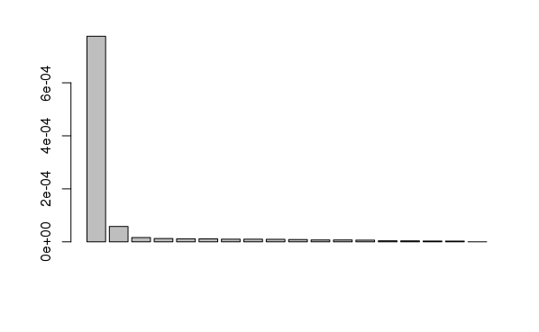

```r
ade4::is.euclid(as.dist(pop_dists),plot=T)
```

Let’s plot a dendogram based on these distances to get an idea of which populations are close to each other.

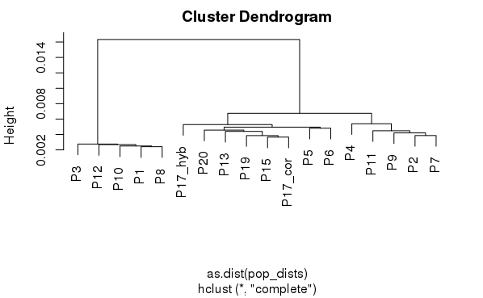

```r
plot(hclust(as.dist(pop_dists)))
```

```r
plant_dist = pop_dists
save(plant_dist,file = 'plant_distances.Rdata')
```